# PCA(DATA MINING WEEK 1)[imp]

```python
import pandas as pd
import numpy as np
import seaborn as sns
import matplotlib.pyplot as plt
```

```python
df=pd.read_excel("Delhi_Pollution_data+%282%29.xlsx")
```

```python
#check first few records
df.head()
```

|  | City | Date | PM2.5 | PM10 | NO | NO2 | NOx | NH3 | CO | SO2 | O3 | Benzene | Toluene | Xylene | AQI | AQI_Bucket |
| --- | --- | --- | --- | --- | --- | --- | --- | --- | --- | --- | --- | --- | --- | --- | --- | --- |
| 0 | Delhi | 2020-07-01 | 54.01 | 128.66 | 6.33 | 21.05 | 16.81 | 29.06 | 0.97 | 11.15 | 29.73 | 2.03 | 23.57 | 0.65 | 101 | Moderate |
| 1 | Delhi | 2020-06-30 | 39.80 | 91.98 | 5.99 | 17.96 | 15.44 | 28.48 | 0.84 | 10.51 | 37.29 | 1.57 | 16.37 | 0.49 | 114 | Moderate |
| 2 | Delhi | 2020-06-29 | 44.86 | 184.12 | 10.50 | 21.57 | 21.94 | 27.97 | 0.88 | 11.58 | 26.61 | 2.13 | 23.80 | 1.13 | 233 | Poor |
| 3 | Delhi | 2020-06-28 | 59.52 | 308.65 | 12.67 | 21.60 | 23.86 | 29.27 | 0.94 | 10.70 | 18.05 | 1.71 | 25.13 | 1.74 | 196 | Moderate |
| 4 | Delhi | 2020-06-27 | 39.80 | 155.94 | 10.88 | 21.46 | 22.47 | 31.43 | 0.87 | 10.38 | 18.88 | 1.69 | 19.99 | 0.43 | 112 | Moderate |

```python
#AQI= air quality index
#AQI is obtained by levels , it is depenent variable ,it depend on the rest of the data
#PCA is a process of independent variable, it is an unsupervised technique (not needed the dependent variable)
#AQI_bucket derived from AQI
```

```python
df.tail()
```

|  | City | Date | PM2.5 | PM10 | NO | NO2 | NOx | NH3 | CO | SO2 | O3 | Benzene | Toluene | Xylene | AQI | AQI_Bucket |
| --- | --- | --- | --- | --- | --- | --- | --- | --- | --- | --- | --- | --- | --- | --- | --- | --- |
| 2004 | Delhi | 2015-01-05 | 146.60 | 219.13 | 14.01 | 34.92 | 38.25 | 122.88 | 9.20 | 3.33 | 23.20 | 2.80 | 6.21 | 2.96 | 325 | Very Poor |
| 2005 | Delhi | 2015-01-04 | 151.84 | 241.84 | 25.01 | 36.91 | 48.62 | 130.36 | 11.54 | 4.63 | 25.36 | 4.26 | 9.71 | 3.34 | 319 | Very Poor |
| 2006 | Delhi | 2015-01-03 | 87.18 | 131.90 | 25.73 | 30.31 | 47.95 | 69.55 | 10.61 | 2.65 | 19.71 | 3.91 | 10.23 | 1.99 | 143 | Moderate |
| 2007 | Delhi | 2015-01-02 | 186.18 | 269.55 | 62.09 | 32.87 | 88.14 | 31.83 | 9.54 | 6.65 | 29.97 | 10.55 | 20.09 | 4.29 | 454 | Severe |
| 2008 | Delhi | 2015-01-01 | 313.22 | 607.98 | 69.16 | 36.39 | 110.59 | 33.85 | 15.20 | 9.25 | 41.68 | 14.36 | 24.86 | 9.84 | 472 | Severe |

```python
df.info()
```

```
<class 'pandas.core.frame.DataFrame'>
RangeIndex: 2009 entries, 0 to 2008
Data columns (total 16 columns):
 #   Column      Non-Null Count  Dtype
---  ------      --------------  -----
 0   City        2009 non-null   object
 1   Date        2009 non-null   datetime64[ns]
 2   PM2.5       2009 non-null   float64
 3   PM10        2009 non-null   float64
 4   NO          2009 non-null   float64
 5   NO2         2009 non-null   float64
 6   NOx         2009 non-null   float64
 7   NH3         2009 non-null   float64
 8   CO          2009 non-null   float64
 9   SO2         2009 non-null   float64
 10  O3          2009 non-null   float64
 11  Benzene     2009 non-null   float64
 12  Toluene     2009 non-null   float64
 13  Xylene      2009 non-null   float64
 14  AQI         2009 non-null   int64
 15  AQI_Bucket  2009 non-null   object
dtypes: datetime64[ns](1), float64(12), int64(1), object(2)
memory usage: 251.2+ KB
```

```python
df.duplicated().sum() #just to avoid any kind of redundancy, we check duplicate value
```

```
0
```

```python
#PCA is the concept that explore the idea of correlation
#and correlation is the concept of paired variable , so u cant have misssing data when u applied pca
```

```python
df.isnull().sum()
```

```
City          0
Date          0
PM2.5         0
PM10          0
NO            0
NO2           0
NOx           0
NH3           0
CO            0
SO2           0
O3            0
Benzene       0
Toluene       0
Xylene        0
AQI           0
AQI_Bucket    0
dtype: int64
```

```python
#drop those columns which are dependent features
df_pca=df.drop(['City','Date','AQI','AQI_Bucket'],axis=1)
```

```python
df_pca.head()
#These are the gases which causing airpollution
```

|  | PM2.5 | PM10 | NO | NO2 | NOx | NH3 | CO | SO2 | O3 | Benzene | Toluene | Xylene |
| --- | --- | --- | --- | --- | --- | --- | --- | --- | --- | --- | --- | --- |
| 0 | 54.01 | 128.66 | 6.33 | 21.05 | 16.81 | 29.06 | 0.97 | 11.15 | 29.73 | 2.03 | 23.57 | 0.65 |
| 1 | 39.80 | 91.98 | 5.99 | 17.96 | 15.44 | 28.48 | 0.84 | 10.51 | 37.29 | 1.57 | 16.37 | 0.49 |
| 2 | 44.86 | 184.12 | 10.50 | 21.57 | 21.94 | 27.97 | 0.88 | 11.58 | 26.61 | 2.13 | 23.80 | 1.13 |
| 3 | 59.52 | 308.65 | 12.67 | 21.60 | 23.86 | 29.27 | 0.94 | 10.70 | 18.05 | 1.71 | 25.13 | 1.74 |
| 4 | 39.80 | 155.94 | 10.88 | 21.46 | 22.47 | 31.43 | 0.87 | 10.38 | 18.88 | 1.69 | 19.99 | 0.43 |

```python
#Check number of features
len(df_pca.columns)
```

```
12
```

# is there any way to find out the optimal variations in the form of principal components where we reduce these features -12 to limited features but remember the 'dimension reduction' would not happen by dropping these variables. the dimension reduction real happend when we priortize the pcs so we will be able to extract for 12 features/12 principle components

A general rule of thumb is : U will have as many as principle component as the number of variables u get in the orignal data, we will be able to extract the 12 principle c but we will apply certain tricks to reduce the principle components and select few pc which have wide control of the data

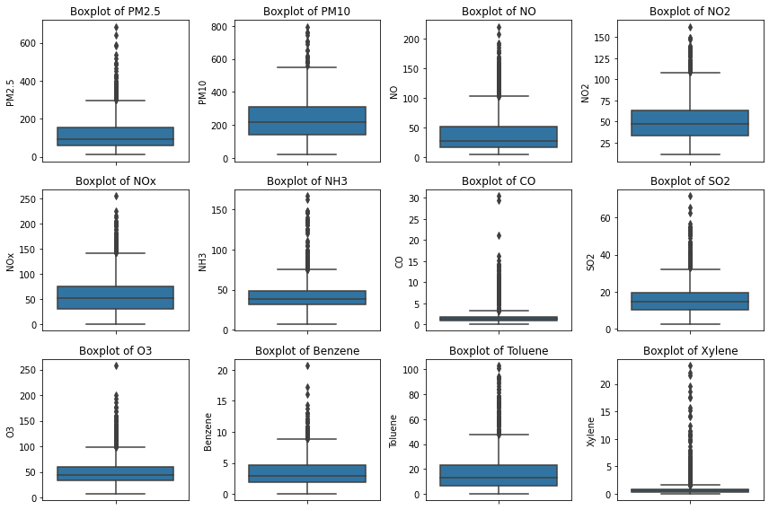

```python
#Check the presence of outliers
plt.figure(figsize=(12,8))
feature_list=df_pca.columns
for i in range(len(feature_list)):
    plt.subplot(3,4,i+1)
    sns.boxplot(y=df_pca[feature_list[i]],data=df_pca)
    plt.title('Boxplot of {}'.format(feature_list[i]))
    plt.tight_layout()
```

```python
#Remove the outliers
def remove_outlier(col):
    Q1,Q3=col.quantile([0.25,0.75])
    IQR=Q3-Q1
    lower_range=Q1-(1.5*IQR)
    upper_range=Q3+(1.5*IQR)
    return lower_range,upper_range
```

```python
for i in feature_list:
    LL,UL=remove_outlier(df_pca[i])
    df_pca[i]=np.where(df_pca[i]>UL,UL,df_pca[i])
    df_pca[i]=np.where(df_pca[i]<LL,LL,df_pca[i])
```

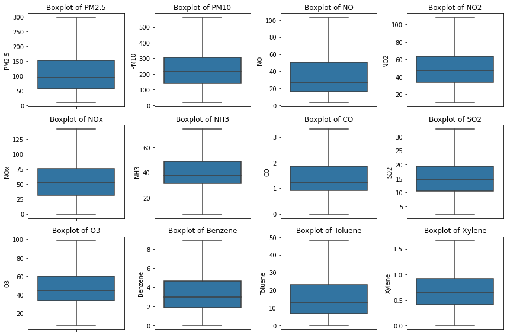

```python
#Check the presence of outliers
plt.figure(figsize=(12,8))
feature_list=df_pca.columns
for i in range(len(feature_list)):
    plt.subplot(3,4,i+1)
    sns.boxplot(y=df_pca[feature_list[i]],data=df_pca)
    plt.title('Boxplot of {}'.format(feature_list[i]))
    plt.tight_layout()
```

```python
df_pca.describe().T  #if we compare from orignal, there is a diff in scale
```

|  | count | mean | std | min | 25% | 50% | 75% | max |
| --- | --- | --- | --- | --- | --- | --- | --- | --- |
| PM2.5 | 2009.0 | 114.304358 | 73.207550 | 10.24 | 57.10 | 94.62 | 152.99 | 296.825 |
| PM10 | 2009.0 | 231.283146 | 116.454530 | 18.59 | 138.81 | 216.73 | 307.38 | 560.235 |
| NO | 2009.0 | 37.080572 | 27.868734 | 3.57 | 15.90 | 27.20 | 50.72 | 102.950 |
| NO2 | 2009.0 | 50.418793 | 21.533088 | 10.63 | 33.90 | 47.15 | 63.57 | 108.075 |
| NOx | 2009.0 | 57.594064 | 34.831204 | 0.00 | 31.15 | 52.75 | 75.36 | 141.675 |
| NH3 | 2009.0 | 41.004778 | 13.629083 | 6.78 | 31.22 | 38.04 | 48.68 | 74.870 |
| CO | 2009.0 | 1.457427 | 0.856552 | 0.00 | 0.91 | 1.24 | 1.87 | 3.310 |
| SO2 | 2009.0 | 15.465983 | 6.480297 | 2.34 | 10.46 | 14.45 | 19.36 | 32.710 |
| O3 | 2009.0 | 49.570667 | 20.892250 | 6.94 | 34.08 | 44.44 | 59.88 | 98.580 |
| Benzene | 2009.0 | 3.480214 | 2.228740 | 0.00 | 1.87 | 2.96 | 4.68 | 8.895 |
| Toluene | 2009.0 | 16.358808 | 12.623484 | 0.00 | 6.65 | 12.75 | 23.20 | 48.025 |
| Xylene | 2009.0 | 0.736013 | 0.522847 | 0.00 | 0.41 | 0.65 | 0.91 | 1.660 |

```python
#Scale the data
from scipy.stats import zscore
df_pca_scaled=df_pca.apply(zscore)
```

```python
#STANDARDIZATION, mean=0 and std dev=1
```

```python
df_pca_scaled.head()
```

|  | PM2.5 | PM10 | NO | NO2 | NOx | NH3 | CO | SO2 | O3 | Benzene | Toluene | Xylene |
| --- | --- | --- | --- | --- | --- | --- | --- | --- | --- | --- | --- | --- |
| 0 | -0.823814 | -0.881449 | -1.103682 | -1.364231 | -1.171197 | -0.876637 | -0.569198 | -0.666182 | -0.949903 | -0.650850 | 0.571394 | -0.164550 |
| 1 | -1.017968 | -1.196500 | -1.115885 | -1.507767 | -1.210540 | -0.919203 | -0.721007 | -0.764968 | -0.587956 | -0.857296 | 0.000887 | -0.470643 |
| 2 | -0.948832 | -0.405093 | -0.954015 | -1.340076 | -1.023879 | -0.956633 | -0.674297 | -0.599811 | -1.099278 | -0.605970 | 0.589619 | 0.753730 |
| 3 | -0.748529 | 0.664518 | -0.876131 | -1.338682 | -0.968742 | -0.861224 | -0.604231 | -0.735641 | -1.509101 | -0.794465 | 0.695004 | 1.767664 |
| 4 | -1.017968 | -0.647136 | -0.940376 | -1.345186 | -1.008659 | -0.702700 | -0.685974 | -0.785033 | -1.469363 | -0.803441 | 0.287725 | -0.585428 |

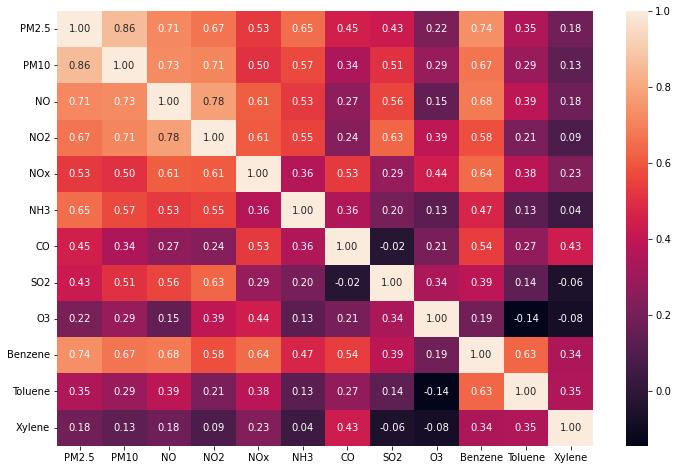

```python
#Check the correlation
plt.figure(figsize=(12,8))
sns.heatmap(df_pca_scaled.corr(), annot=True, fmt='.2f');
```

```python
#There r corelation,
#PCA treat multicolinearitY in the data
#if correaltions r not present in the data, pca is not good for u
```

```python
#wetaher this corelation is significant or not we use,
#STATISTICAL TEST =BARTLEt test of sphericity to check the coliniearity
```

```python
#H0= correlations are not significant , H1 = significant correlation
#reject H0 if p-value <0.05
from factor_analyzer.factor_analyzer import calculate_bartlett_sphericity
chi_square_value,p_value=calculate_bartlett_sphericity(df_pca_scaled)
p_value
```

```
0.0
```

```python
#p value = 0 is smaller than 0.05 we conclude that significant correlaetion exists
#what if it is greater than 0.05 it means all next steps r terminated (no nned for pca)
```

```python
#Confirm the adequacy of sample size. - also a pre requisite
#Note: Above 0.7 is good, below *0.5* is not acceptable (should be greater thn 0.7)
from factor_analyzer.factor_analyzer import calculate_kmo
kmo_all,kmo_model=calculate_kmo(df_pca_scaled)
kmo_model

#greater thn 0.7 we have adequeate sample to proceed with
#if less than 0.5 thn u have to collect more data
```

```
0.8377873137578513
```

```python
#Apply PCA taking all features
from sklearn.decomposition import PCA
pca = PCA(n_components=12, random_state=123) #random state for consistency , if me or anyone else run this code, get same result
pca_transformed = pca.fit_transform(df_pca_scaled)
```

```python
#Extract eigen vectors
pca.components_

#these are pc1[.........], pc2[.........] or eigen vector
```

```
array([[ 0.36757983,  0.35874864,  0.3586897 ,  0.34856375,  0.31661476,
         0.27264851,  0.22407402,  0.2354441 ,  0.14900296,  0.35967138,
         0.20036925,  0.11870582],
       [ 0.01788055,  0.12180783,  0.07920562,  0.25502423, -0.07185109,
         0.06976372, -0.37463646,  0.38778796,  0.33653904, -0.20718676,
        -0.41848144, -0.53052722],
       [-0.10244197, -0.1082965 , -0.23877719, -0.02680145,  0.329494  ,
        -0.04259609,  0.46126311, -0.1934286 ,  0.65938621, -0.06805854,
        -0.32861601,  0.10988637],
       [ 0.2517615 ,  0.14172243, -0.04998115, -0.05800976, -0.19614686,
         0.64557842,  0.21025355, -0.42214395, -0.25004424, -0.10221822,
        -0.35987447, -0.17472887],
       [-0.02951417, -0.10587218, -0.06664532, -0.15232101,  0.3156141 ,
         0.03492092,  0.00652305, -0.27840717,  0.07088788,  0.1881715 ,
         0.44708658, -0.73591565],
       [-0.33778676, -0.35252369,  0.38787525,  0.34686121,  0.49700404,
         0.18451077, -0.20320897, -0.22301716, -0.21810356, -0.20738014,
        -0.12560924,  0.11147241],
       [ 0.06563324,  0.12375596, -0.14457983,  0.02262857, -0.09388006,
         0.27700264, -0.60703311, -0.36527962,  0.44866553, -0.02001182,
         0.28029185,  0.30205016],
       [ 0.27566473,  0.46946395,  0.19819553, -0.05234811,  0.21837965,
        -0.5669765 , -0.15271419, -0.43768945, -0.10139654, -0.09041726,
        -0.24071278, -0.03385089],
       [ 0.08630889, -0.19256102,  0.12658272, -0.57691351,  0.22711834,
         0.11542776, -0.29822569,  0.13555367, -0.00258175,  0.53123794,
        -0.38061592,  0.08549909],
       [-0.12323599, -0.21886613,  0.15580356,  0.42173106, -0.44643724,
        -0.19386918,  0.03258363, -0.32222979,  0.10317314,  0.58920379,
        -0.16743865, -0.08456931],
       [-0.16435551,  0.01597716,  0.73600924, -0.38536644, -0.30252698,
         0.03979365,  0.17069172, -0.06325655,  0.29371465, -0.2245804 ,
         0.13633232, -0.03131745],
       [ 0.73876135, -0.60680943,  0.09205628,  0.05849928, -0.04486307,
        -0.12751874, -0.01360063, -0.01047633,  0.07830299, -0.21407386,
         0.05971928,  0.00486172]])
```

```python
#Check the eigen values  #if we have 12 pcs above it means we have 12 eigen values . each pc has 1 unit of eigen value
#note:- This is always returned in descending order
pca.explained_variance_
```

```
array([5.71418983, 1.73516949, 1.14758734, 0.95455182, 0.63944041,
       0.46998204, 0.36503474, 0.34686872, 0.1906889 , 0.16883957,
       0.15442402, 0.11919921])
```

```python
#Check the explained variance for each PC
#Note: Explained variance = (eigen value of each PC)/(sum of eigen values of all PCs) means % 12
pca.explained_variance_ratio_

#0.47594546 means= pc1 alone captures the 47.5% of th variability
#first pc is always imortant (descending order)
```

```
array([0.47594546, 0.14452548, 0.09558468, 0.07950639, 0.05326018,
       0.03914568, 0.03040442, 0.02889134, 0.01588283, 0.01406296,
       0.01286226, 0.00992832])
```

```python
#Create a dataframe containing the loadings or coefficients of all PCs
df_extracted_loadings = pd.DataFrame(pca.components_.T,
                                     columns = ['PC1','PC2', 'PC3', 'PC4', 'PC5', 'PC6',
                                               'PC7','PC8', 'PC9', 'PC10', 'PC11', 'PC12'],
                                    index = df_pca_scaled.columns)
```

```python
df_extracted_loadings
```

|  | PC1 | PC2 | PC3 | PC4 | PC5 | PC6 | PC7 | PC8 | PC9 | PC10 | PC11 | PC12 |
| --- | --- | --- | --- | --- | --- | --- | --- | --- | --- | --- | --- | --- |
| PM2.5 | 0.367580 | 0.017881 | -0.102442 | 0.251761 | -0.029514 | -0.337787 | 0.065633 | 0.275665 | 0.086309 | -0.123236 | -0.164356 | 0.738761 |
| PM10 | 0.358749 | 0.121808 | -0.108297 | 0.141722 | -0.105872 | -0.352524 | 0.123756 | 0.469464 | -0.192561 | -0.218866 | 0.015977 | -0.606809 |
| NO | 0.358690 | 0.079206 | -0.238777 | -0.049981 | -0.066645 | 0.387875 | -0.144580 | 0.198196 | 0.126583 | 0.155804 | 0.736009 | 0.092056 |
| NO2 | 0.348564 | 0.255024 | -0.026801 | -0.058010 | -0.152321 | 0.346861 | 0.022629 | -0.052348 | -0.576914 | 0.421731 | -0.385366 | 0.058499 |
| NOx | 0.316615 | -0.071851 | 0.329494 | -0.196147 | 0.315614 | 0.497004 | -0.093880 | 0.218380 | 0.227118 | -0.446437 | -0.302527 | -0.044863 |
| NH3 | 0.272649 | 0.069764 | -0.042596 | 0.645578 | 0.034921 | 0.184511 | 0.277003 | -0.566976 | 0.115428 | -0.193869 | 0.039794 | -0.127519 |
| CO | 0.224074 | -0.374636 | 0.461263 | 0.210254 | 0.006523 | -0.203209 | -0.607033 | -0.152714 | -0.298226 | 0.032584 | 0.170692 | -0.013601 |
| SO2 | 0.235444 | 0.387788 | -0.193429 | -0.422144 | -0.278407 | -0.223017 | -0.365280 | -0.437689 | 0.135554 | -0.322230 | -0.063257 | -0.010476 |
| O3 | 0.149003 | 0.336539 | 0.659386 | -0.250044 | 0.070888 | -0.218104 | 0.448666 | -0.101397 | -0.002582 | 0.103173 | 0.293715 | 0.078303 |
| Benzene | 0.359671 | -0.207187 | -0.068059 | -0.102218 | 0.188172 | -0.207380 | -0.020012 | -0.090417 | 0.531238 | 0.589204 | -0.224580 | -0.214074 |
| Toluene | 0.200369 | -0.418481 | -0.328616 | -0.359874 | 0.447087 | -0.125609 | 0.280292 | -0.240713 | -0.380616 | -0.167439 | 0.136332 | 0.059719 |
| Xylene | 0.118706 | -0.530527 | 0.109886 | -0.174729 | -0.735916 | 0.111472 | 0.302050 | -0.033851 | 0.085499 | -0.084569 | -0.031317 | 0.004862 |

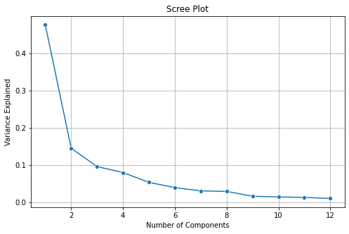

```python
#Create a scree plot
plt.figure(figsize=(8,5))
sns.lineplot(y=pca.explained_variance_ratio_ ,x=range(1,13),marker='o')
plt.xlabel('Number of Components',fontsize=10)
plt.ylabel('Variance Explained',fontsize=10)
plt.title('Scree Plot',fontsize=12)
plt.grid()
plt.show()
```

```python
#Check the cumlative explained variance ratio to find a cut off for selecting the number of PCs
np.cumsum(pca.explained_variance_ratio_)

#here we see 80% of the data till 5th pc, so these r imp , we can pritorize
```

```
array([0.47594546, 0.62047094, 0.71605562, 0.79556201, 0.84882219,
       0.88796786, 0.91837228, 0.94726362, 0.96314645, 0.97720941,
       0.99007168, 1.        ])
```

```python
#Choose the PCs basis cumulative explained variance
df_selected = df_extracted_loadings[['PC1','PC2', 'PC3', 'PC4', 'PC5']]  #so we select 5 pcs only #Check the selected PCs
df_selected
```

|  | PC1 | PC2 | PC3 | PC4 | PC5 |
| --- | --- | --- | --- | --- | --- |
| PM2.5 | 0.367580 | 0.017881 | -0.102442 | 0.251761 | -0.029514 |
| PM10 | 0.358749 | 0.121808 | -0.108297 | 0.141722 | -0.105872 |
| NO | 0.358690 | 0.079206 | -0.238777 | -0.049981 | -0.066645 |
| NO2 | 0.348564 | 0.255024 | -0.026801 | -0.058010 | -0.152321 |
| NOx | 0.316615 | -0.071851 | 0.329494 | -0.196147 | 0.315614 |
| NH3 | 0.272649 | 0.069764 | -0.042596 | 0.645578 | 0.034921 |
| CO | 0.224074 | -0.374636 | 0.461263 | 0.210254 | 0.006523 |
| SO2 | 0.235444 | 0.387788 | -0.193429 | -0.422144 | -0.278407 |
| O3 | 0.149003 | 0.336539 | 0.659386 | -0.250044 | 0.070888 |
| Benzene | 0.359671 | -0.207187 | -0.068059 | -0.102218 | 0.188172 |
| Toluene | 0.200369 | -0.418481 | -0.328616 | -0.359874 | 0.447087 |
| Xylene | 0.118706 | -0.530527 | 0.109886 | -0.174729 | -0.735916 |

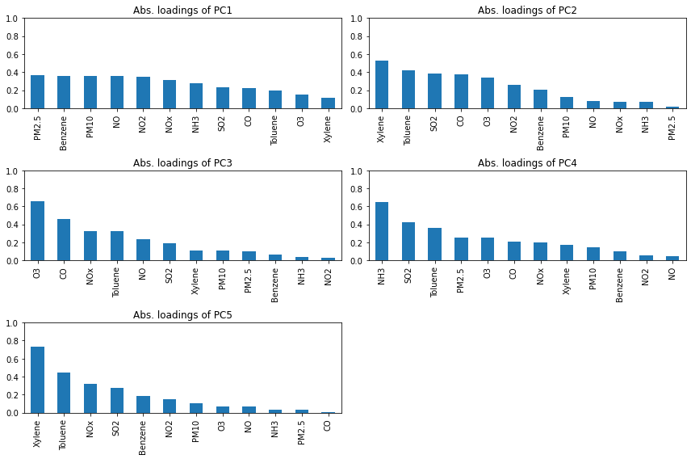

```python
#Check as to how the original features matter to each PC
#Note: Here we are only considering the absolute values
plt.figure(figsize = (12,8))
for i in range(len(df_selected.columns)):
    plt.subplot(3,2,i+1)
    abs(df_selected[df_selected.columns[i]]).T.sort_values(ascending = False).plot.bar()
    plt.yticks(np.arange(0,1.2,.2))
    plt.title('Abs. loadings of {}'.format(df_selected.columns[i]))
    plt.tight_layout()
```

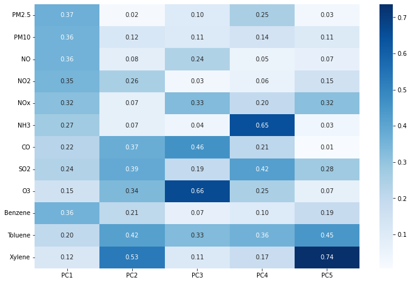

```python
#Compare how the original features influence various PCs
plt.figure(figsize = (12,8))
sns.heatmap(abs(df_selected), annot = True, cmap = 'Blues',fmt = '.2f');

#(see horizontally)
#as we know pc1 captures the most important info from the data , so we can see PM2.5 has high magnitude in pc1
#PM10 is dominant in pc1 not anywhere else
#NOx is overlapping , but as weknow pc1 in priotirising
#amonia is pretty high in pc4 like wise xylene is high in pc5
```

```python
#in order to calculate the pc score  we need loadings
df_selected
```

|  | PC1 | PC2 | PC3 | PC4 | PC5 |
| --- | --- | --- | --- | --- | --- |
| PM2.5 | 0.367580 | 0.017881 | -0.102442 | 0.251761 | -0.029514 |
| PM10 | 0.358749 | 0.121808 | -0.108297 | 0.141722 | -0.105872 |
| NO | 0.358690 | 0.079206 | -0.238777 | -0.049981 | -0.066645 |
| NO2 | 0.348564 | 0.255024 | -0.026801 | -0.058010 | -0.152321 |
| NOx | 0.316615 | -0.071851 | 0.329494 | -0.196147 | 0.315614 |
| NH3 | 0.272649 | 0.069764 | -0.042596 | 0.645578 | 0.034921 |
| CO | 0.224074 | -0.374636 | 0.461263 | 0.210254 | 0.006523 |
| SO2 | 0.235444 | 0.387788 | -0.193429 | -0.422144 | -0.278407 |
| O3 | 0.149003 | 0.336539 | 0.659386 | -0.250044 | 0.070888 |
| Benzene | 0.359671 | -0.207187 | -0.068059 | -0.102218 | 0.188172 |
| Toluene | 0.200369 | -0.418481 | -0.328616 | -0.359874 | 0.447087 |
| Xylene | 0.118706 | -0.530527 | 0.109886 | -0.174729 | -0.735916 |

```python
#...and we need the original scaled features
df_pca_scaled.iloc[0]
```

```
PM2.5     -0.823814
PM10      -0.881449
NO        -1.103682
NO2       -1.364231
NOx       -1.171197
NH3       -0.876637
CO        -0.569198
SO2       -0.666182
O3        -0.949903
Benzene   -0.650850
Toluene    0.571394
Xylene    -0.164550
Name: 0, dtype: float64
```

```python
#We need to perform a dot product between the loadings and features to obtain the scores
for i in df_selected.columns:
    pc_score = np.dot(df_selected[i], df_pca_scaled.iloc[0]) #here we take only one row by the help of .iloc[0] but in real it is done for all row in the data
    print(round(pc_score, 6), end = ' ')  #6 decimal places

# yes we can say that pca is the transformation on the data which treats the collinearity in the data
#without compromising the quality of the information  with the orignal data that was provide u
#
```

```
-2.665334 -0.91618 -0.790212 -0.245518 0.367239
```

#orignal data is input[50] PM2.5 -0.823814 PM10 -0.881449 NO -1.103682 NO2 -1.364231 NOx -1.171197 NH3 -0.876637 CO -0.569198 SO2 -0.666182 O3 -0.949903 Benzene -0.650850 Toluene 0.571394 Xylene -0.164550 Name: 0, dtype: float64 these 12 feature now reduce in to 5 :- [ -2.665334 -0.91618 -0.790212 -0.245518 0.367239 ] #this is only for 1 row - --df_pca_scaled.iloc[0]-- 0 represent 1st row only, Same for other rows also, just change the number 0 to 1,2,3,4, etc..

```python
#so we cant do this for every row, so we have a way to do this--
```

```python
 # instead of 12 write 5 - n_components=5
```

```python
#Above step involves a lot of hard work. Let's do it the easier way
#Extract the required(as per the cumulative explained variance) number of PCs
pca = PCA(n_components=5, random_state=123)   #.fit
pca_final = pca.fit_transform(df_pca_scaled)   #it give output
```

```python
#Just create a dataframe out of fit_transformed scaled data above
#Note: Notice the output of cell 34 and the first row of the dataframe below
pca_final_df = pd.DataFrame(pca_final, columns = df_selected.columns)
pca_final_df.head(10)
```

|  | PC1 | PC2 | PC3 | PC4 | PC5 |
| --- | --- | --- | --- | --- | --- |
| 0 | -2.665334 | -0.916180 | -0.790212 | -0.245518 | 0.367239 |
| 1 | -3.156439 | -0.411456 | -0.384953 | -0.150697 | 0.398613 |
| 2 | -2.354841 | -1.347799 | -0.881378 | -0.483265 | -0.338393 |
| 3 | -1.829266 | -1.964523 | -1.144289 | -0.255720 | -1.167517 |
| 4 | -2.781773 | -0.676409 | -1.105102 | 0.156680 | 0.541447 |
| 5 | -2.552951 | -1.016836 | -0.896148 | -0.122146 | 0.308240 |
| 6 | -2.974647 | -0.688794 | -0.713432 | -0.076641 | 0.467709 |
| 7 | -3.461293 | -0.243401 | -0.666444 | 0.260655 | 0.516457 |
| 8 | -3.394853 | -0.254105 | -0.564833 | 0.252188 | 0.474779 |
| 9 | -2.949465 | -0.223915 | -0.256325 | -0.014562 | 0.662630 |

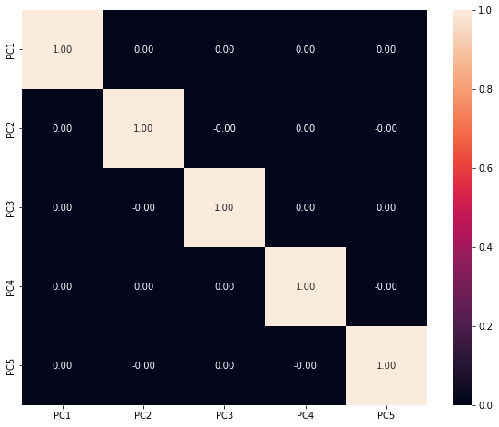

```python
#Check for presence of correlations among teh PCs
plt.figure(figsize = (10,8))
sns.heatmap(pca_final_df.corr(), annot=True,fmt='.2f');
```

```python
#compare to 12 i have 5 features
#pca adresses the problm of multicollinearity
#here we see variables 0 , 0 only diagonals are 1


#CONCLUSION: PCA treats- multicollinearity, reduce the dimensions in the data, pca is the transformation in the data
```